# Practical Machine Learning Course Project.

Sergey Zimin

Sep-11-2016

## Introduction and Background

This is the final course project for the **Practical Machine Learning** Course on Coursera.

Using devices such as Jawbone Up, Nike FuelBand, and Fitbit it is now possible to collect a large amount of data about personal activity relatively inexpensively. These type of devices are part of the quantified self movement – a group of enthusiasts who take measurements about themselves regularly to improve their health, to find patterns in their behavior, or because they are tech geeks.

One thing that people regularly do is quantify how much of a particular activity they do, but they rarely quantify how well they do it. In this project, my goal will be to use data from accelerometers on the belt, forearm, arm, and dumbell of 6 participants. They were asked to perform barbell lifts correctly and incorrectly in 5 different ways. More information is available from the website here: http://groupware.les.inf.puc-rio.br/har (see the section on the Weight Lifting Exercise Dataset).

The goal of the project is to predict the manner in which they did the exercise. This is the “classe” variable in the training set. It’s allowed to use any of the other variables to predict with. This report is describing how I built the model, how I used cross validation, what I think the expected out of sample error is, and why I made the choices I did.

## Data

The training data for this project are available here: https://d396qusza40orc.cloudfront.net/predmachlearn/pml-training.csv  
The test data are available here: https://d396qusza40orc.cloudfront.net/predmachlearn/pml-testing.csv

## Loading data

First I get the datasets files from the links. Then I create datasets for both files and load needed libraries.

```r
## Setting time of data download
print(Sys.time())
```

```
## [1] "2016-09-12 01:51:31 MSK"
```

```r
## Loading data
urltr <- "https://d396qusza40orc.cloudfront.net/predmachlearn/pml-training.csv"
urlts <- "https://d396qusza40orc.cloudfront.net/predmachlearn/pml-testing.csv"
training <- read.csv(urltr)
testing <- read.csv(urlts)
```

I will use [caret](https://cran.r-project.org/web/packages/caret/index.html) package for building models and [ggplot2](https://cran.r-project.org/web/packages/ggplot2/index.html) package for plotting. Also packages [rpart](https://cran.r-project.org/web/packages/rpart/index.html) and [randomForest](https://cran.r-project.org/web/packages/randomForest/index.html) will be used by the **train** function to build the models.

```r
## Loading needed libraries
suppressMessages(library(caret))
suppressMessages(library(ggplot2))
suppressMessages(library(rpart))
suppressMessages(library(randomForest))
```

## Exploratory analysis

As the next step I am checking the datasets.

```r
## Checking data
dim(training)
```

```
## [1] 19622   160
```

```r
dim(testing)
```

```
## [1]  20 160
```

```r
head(names(training), 10)
```

```
##  [1] "X"                    "user_name"            "raw_timestamp_part_1"
##  [4] "raw_timestamp_part_2" "cvtd_timestamp"       "new_window"
##  [7] "num_window"           "roll_belt"            "pitch_belt"
## [10] "yaw_belt"
```

```r
tail(names(training), 10)
```

```
##  [1] "gyros_forearm_x"  "gyros_forearm_y"  "gyros_forearm_z"
##  [4] "accel_forearm_x"  "accel_forearm_y"  "accel_forearm_z"
##  [7] "magnet_forearm_x" "magnet_forearm_y" "magnet_forearm_z"
## [10] "classe"
```

```r
summary(training$classe)
```

```
##    A    B    C    D    E
## 5580 3797 3422 3216 3607
```

I can see that there are 160 variables in total in the dataset. Most of them are data from the sensors, there are also timestamps data, a variable indicating the experiments participants and an indexing variable. I can also see that training dataset is big enough so I can split it to training and probe sets to evaluate out of sample error rate with cross validation.

```r
## Splitting testing data into train and probe datasets
set.seed(123)
inProbe <- createDataPartition(training$classe, p = 0.6, list = FALSE)
train <- training[-inProbe,]
probe <- training[inProbe,]
```

Then I build a couple of feature plots to check the data. I can see there that the belt sensor could be a good predictor for a model.

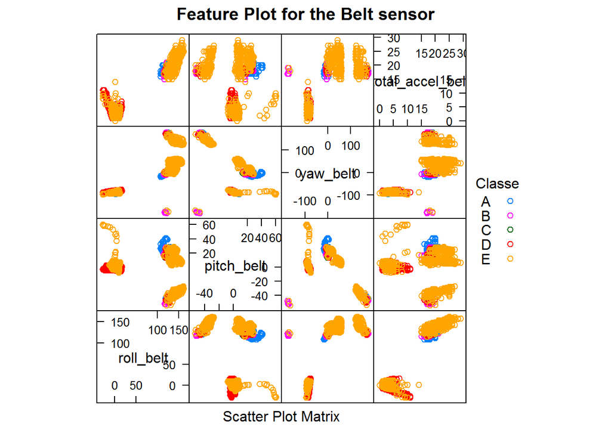

```r
## Building exploratory plots
beltCols <- grep("belt$", names(train), value = TRUE)
featurePlot(x=train[,beltCols[1:4]]
            , y=train$classe
            , plot = "pairs"
            , main = "Feature Plot for the Belt sensor"
            , auto.key=list(space="right"
                            , title="Classe"
                            , cex.title=1
                            , points=TRUE))
```

*Figure 1. Feature Plot for the Belt sensor*

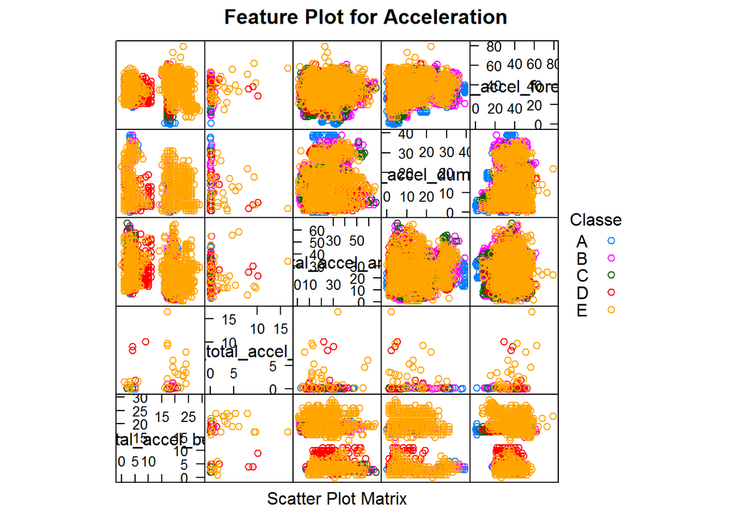

```r
accelCols <- grep("total_accel", names(train), value = TRUE)
featurePlot(x=train[,accelCols]
            , y=train$classe
            , plot = "pairs"
            , main = "Feature Plot for Acceleration"
            , auto.key=list(space="right"
                            , title="Classe"
                            , cex.title=1
                            , points=TRUE))
```

*Figure 2. Feature Plot for Acceleration*

## Data preprocessing and features selection

I can see no need to preprocess the data. So as the next step I’ve decided only to remove some variables from the features set:  
1. Variables with too many NAs  
2. Variables with near zero variance  
3. Timestamps, windows, participants and indexing variables as from my perspective these would not add any value to the prediction but could cause ovetfitting.

```r
## Removing predictors with too many NAs, near zero variability and index variable
naShare <- sapply(train, function (x) mean(is.na(x)))
unique(naShare)
```

```
## [1] 0.0000000 0.9798624
```

```r
tooManyNAs <- names(naShare[naShare > .5])

nzvData <- nearZeroVar(train, saveMetrics = TRUE)
isNZV <- row.names(nzvData[nzvData$nzv,])

isTmstamps <- grep("timestamp", names(train), value = TRUE)
isWindow <- grep("window", names(train), value = TRUE)

colsToExclude <- unique(c(tooManyNAs
                          , isNZV
                          , isTmstamps
                          , isWindow
                          , names(train)[1:6]))

trainClr <- train[,!(names(train) %in% colsToExclude)]
```

## Models creation and selecting

Then I’m building two prediction models with methods **“Decision tree”** and **“Random Forest”**. I decided to use these models as they both are apropriate for multifactorial dependent variables and Random Forest is also one of the most accurate ones. I use cross validation with **2 folds** for both models and **100 trees** for the Random Forest modelling. I’ve chosen these figures as I just started with some small numbers and it turned out these were enough to get an almost perfect prediction.

```r
## Setting cross validation folds number
trControl <- trainControl(method = "cv", number = 2)
```

### Decision Tree Model

I build the standard decision tree model with **rpart** method of the caret’s **train** function

```r
## Decision tree
set.seed(123)
fit <- train(classe ~., data = trainClr, method = "rpart", trControl=trControl)
trainPr <- predict(fit, trainClr)
confusionMatrix(trainPr, trainClr$classe)
```

```
## Confusion Matrix and Statistics
##
##           Reference
## Prediction    A    B    C    D    E
##          A 2031  641  655  580  222
##          B   27  515   40  203  210
##          C  166  362  673  503  373
##          D    0    0    0    0    0
##          E    8    0    0    0  637
##
## Overall Statistics
##
##                Accuracy : 0.4915
##                  95% CI : (0.4803, 0.5026)
##     No Information Rate : 0.2845
##     P-Value [Acc > NIR] : < 2.2e-16
##
##                   Kappa : 0.3348
##  Mcnemar's Test P-Value : NA
##
## Statistics by Class:
##
##                      Class: A Class: B Class: C Class: D Class: E
## Sensitivity            0.9099  0.33926  0.49196   0.0000  0.44175
## Specificity            0.6263  0.92415  0.78327   1.0000  0.99875
## Pos Pred Value         0.4919  0.51759  0.32403      NaN  0.98760
## Neg Pred Value         0.9459  0.85360  0.87953   0.8361  0.88821
## Prevalence             0.2845  0.19347  0.17436   0.1639  0.18379
## Detection Rate         0.2589  0.06564  0.08578   0.0000  0.08119
## Detection Prevalence   0.5263  0.12682  0.26472   0.0000  0.08221
## Balanced Accuracy      0.7681  0.63170  0.63761   0.5000  0.72025
```

### Random Forest Model

I build a random forest model of **100 trees** with **rf** method.

```r
## Random forest
set.seed(123)
fit2 <- train(classe ~., data = trainClr, method = "rf", ntree=100, trControl=trControl)
trainPr2 <- predict(fit2, trainClr)
confusionMatrix(trainPr2, trainClr$classe)
```

```
## Confusion Matrix and Statistics
##
##           Reference
## Prediction    A    B    C    D    E
##          A 2232    0    0    0    0
##          B    0 1518    0    0    0
##          C    0    0 1368    0    0
##          D    0    0    0 1286    0
##          E    0    0    0    0 1442
##
## Overall Statistics
##
##                Accuracy : 1
##                  95% CI : (0.9995, 1)
##     No Information Rate : 0.2845
##     P-Value [Acc > NIR] : < 2.2e-16
##
##                   Kappa : 1
##  Mcnemar's Test P-Value : NA
##
## Statistics by Class:
##
##                      Class: A Class: B Class: C Class: D Class: E
## Sensitivity            1.0000   1.0000   1.0000   1.0000   1.0000
## Specificity            1.0000   1.0000   1.0000   1.0000   1.0000
## Pos Pred Value         1.0000   1.0000   1.0000   1.0000   1.0000
## Neg Pred Value         1.0000   1.0000   1.0000   1.0000   1.0000
## Prevalence             0.2845   0.1935   0.1744   0.1639   0.1838
## Detection Rate         0.2845   0.1935   0.1744   0.1639   0.1838
## Detection Prevalence   0.2845   0.1935   0.1744   0.1639   0.1838
## Balanced Accuracy      1.0000   1.0000   1.0000   1.0000   1.0000
```

I can see that accuracy of the random forest is much better than the one of the decision tree, and also it looks perfect, so from my perspective it worth using this model for the prediction.  
Now I apply the random forest model to the probe dataset.

```r
probePr2 <- predict(fit2, probe)
confusionMatrix(probePr2, probe$classe)
```

```
## Confusion Matrix and Statistics
##
##           Reference
## Prediction    A    B    C    D    E
##          A 3334   41    0    0    0
##          B    9 2212   16    1    3
##          C    4   25 2028   38    3
##          D    0    1   10 1888    5
##          E    1    0    0    3 2154
##
## Overall Statistics
##
##                Accuracy : 0.9864
##                  95% CI : (0.9842, 0.9884)
##     No Information Rate : 0.2843
##     P-Value [Acc > NIR] : < 2.2e-16
##
##                   Kappa : 0.9828
##  Mcnemar's Test P-Value : NA
##
## Statistics by Class:
##
##                      Class: A Class: B Class: C Class: D Class: E
## Sensitivity            0.9958   0.9706   0.9873   0.9782   0.9949
## Specificity            0.9951   0.9969   0.9928   0.9984   0.9996
## Pos Pred Value         0.9879   0.9871   0.9666   0.9916   0.9981
## Neg Pred Value         0.9983   0.9930   0.9973   0.9957   0.9989
## Prevalence             0.2843   0.1935   0.1744   0.1639   0.1838
## Detection Rate         0.2831   0.1878   0.1722   0.1603   0.1829
## Detection Prevalence   0.2866   0.1903   0.1782   0.1617   0.1833
## Balanced Accuracy      0.9955   0.9838   0.9901   0.9883   0.9973
```

## Out of Sample Error

I can see that accuracy is still very high. So it’s time to calculate an out of sample error rate. I use prob dataset which was cut from the training data set to get a cross validation based OOS error.

```r
oos <- round(sum(probePr2 != probe$classe)/length(probe$classe)*100, 2)
```

The expected OOS is **1.36%**.

As the final step I apply the model to the testing dataset to get answers for the Quiz.

```r
testPr <- predict(fit2, testing)
```

So the answer is **B, A, A, A, A, E, D, B, A, A, B, C, B, A, E, E, A, B, B, B**.